# Drift Centered Baeysian Kalman Filter with Gibbs Sampling

Zach

6/23/2020

# The Model

Let $y_t$ be a $n \times 1$ vector where the $i^{th}$ entry is the $i^{th}$ subject’s $t^{th}$ measurement of some outcome. Then the matrix $X_t$ is a $n \times p$ matrix where $[X_t]_{ij}$ is the $j^{th}$ covariate of the $i^{th}$ subject at time $t$. Our aim is to estimate $\beta$ from the model,

$$\begin{equation}
\begin{aligned}
y_t &= \mu_t + X_t \beta +\varepsilon_t\\
\mu_t &= \mu_{t-1} + \eta_t
\end{aligned}
\end{equation}$$

where $\varepsilon_t \sim N(0, \sigma^2_\varepsilon I_n)$, $\eta_t \sim N(0, \sigma^2_\eta I_n)$, and $\mu_0\sim N(u_0, P_0)$ for some vector $u_0$ and some positive valued diagnol matrix $P_0$.

We also have the following prior distributions,

$$\begin{equation}
\begin{aligned}
\beta &\sim N(\theta, \sigma^2_\beta)\\
\sigma^2_\eta &\sim IG(a_0/2, b_0/2)\\
\sigma^2_\varepsilon &\sim IG(c_0/2,d_0/2)
\end{aligned}
\end{equation}$$

The Kalman Filter can be used to jointly estimate $\mu_t$ and $\beta$, however there is a computational advantage estimating $\mu_t|\beta$ then $\beta|\mu$ through a Gibbs sampling approach.

# Posterior Distributions

For notational ease, let $Y = [y_1, ..., y_T]$, $\mu = [\mu_1, ..., \mu_T]$, $X = [X_1, ..., X_T]$

## $\mu|Y, X, \beta, \sigma^2_\eta, \sigma^2_\varepsilon$

(This is a modification of Shumway and Stoeffer pg 368)

The conditional distribution $\mu|Y, X, \beta, \sigma^2_\eta, \sigma^2_\varepsilon$ can be estimated directly from the the Kalman Filter. By conditioning on $X_t$ and $\beta$ each $[y_t]_i$ is independent at each time point $t$. Thus we can run the Kalman Filter with $y^*_t = y_t - X_t \beta$ as the outcome in the model,

$$\begin{equation}
\begin{aligned}
y^*_t &= \mu_t +\varepsilon_t\\
\mu_t &= \mu_{t-1} + \eta_t
\end{aligned}
\end{equation}$$

Because the $y^*_t$ are independent it is equivalent to estimating the $[\mu_t]_i$ individually resulting in a computational efficient Kalman Filter where,

$$\begin{equation}
\begin{aligned}
u_t^{t-1} = u_{t-1}^{t-1}, \ \ \ & P_t^{t-1} = P_{t-1}^{t-1} + \sigma^2_\eta\\
u_{t}^t = u_t^{t-1} + K_t (y_t^*- u_t^{t-1}), \ \ \ & P_{t}^t = (1-K_t)P_{t}^{t-1}\\
K_t = \frac{P_{t}^{t-1}}{P_{t}^{t-1} + \sigma^2_\varepsilon}
\end{aligned}
\end{equation}$$

Let $\psi = \{\sigma^2_\eta, \sigma^2_\varepsilon, \beta\}$Here, $u_i^j = E_\psi(\mu_i|y_{1:j})$ and $P_i^j = var_\psi(\mu_i|y_{1:j})$.

Although we are using vectors, because of the independence each operation is done element-wise. To get $u_t^n = E_\psi(\mu_t|y_{1:n})$ and $P_t^n = var_\psi(\mu_t|y_{1:n})$ we need the backward recursions starting with $J_n = 0$,

$$\begin{equation}
\begin{aligned}
u_{t-1}^n = u_{t-1}^{t-1} + J_{t-1}(u_t^n - u_t^{t-1})\\
P_{t-1}^n = P_{t-1}^{t-1} + J_{t-1}^2 (P^n_t-P^{t-1}_t)\\
J_{t-1} = \frac{P^{t-1}_{t-1}}{P_t^{t-1}}
\end{aligned}
\end{equation}$$

For the posterior of $\mu$ we want,

$$\begin{equation}
\begin{aligned}
P_\psi(\mu{0:n}|y_{1:n}) &= P_\psi(\mu_n|y_{1:n})P_\psi(\mu_{n-1}|\mu_n, y_{1:n}) ... P_\psi(\mu_0|\mu_{1:n}, y_{1:n}.)\\
&= P_\psi(\mu_n|y_{1:n})P_\psi(\mu_{n-1}|\mu_n, y_{1:(n-1)}) ... P_\psi(\mu_0|\mu_1)
\end{aligned}
\end{equation}$$

Therefore we need the densities,

$$\begin{equation}
\begin{aligned}
p_\psi(\mu_t|\mu_{t+1}, y_{1:t}) \propto p_\psi(\mu_t| y_{1:t})p_\psi(\mu_{t+1}| \mu_t)
\end{aligned}
\end{equation}$$

Because of the normality assumption we know that $\mu_t|y_{1:t} \sim N_\psi(u_t^t, P_t^t)$ and $\mu_{t+1}|\mu_t \sim N_\psi(\mu_t, \sigma^2_\eta)$. After completing some algebra we find $m_t = E_\psi(\mu_t| \mu_{t+1}y_{1:t}) = u^t_t + J_t (\mu_{t+1} - u^t_{t+1})$ and $V_t = P_t^t - J_t^2 P_{t+1}^t$. Therefore, the posterior distribution for $\mu_t$ is $N(m_t, V_t)$.

For the backward sampling procedure we start by sampling a $\mu_n^*$ from a $N_\psi(m_n, V_n)$, then setting $\mu_n^* = \mu_n$ in the calculation of $m_{n-1}$ to then sample $\mu_{n-1}^*$ from a $N_\psi(m_{n-1}, V_{n-1})$. This process continues until a whole chain $\mu_{1:n}^*$ has been sampled.

## $\beta|Y, X, \mu, \sigma^2_\eta, \sigma^2_\varepsilon$

With all the other parameters fixed,

$$\begin{equation}
\begin{aligned}
P(\beta|...) = \frac{P(...|\beta)P(\beta)}{P(...)}
\end{aligned}
\end{equation}$$

Because $P(...)$ is constant with respect to $\beta$ and $P(\beta)$ is already defined we focus our attention on $P(...|\beta)$.

$$\begin{equation}
\begin{aligned}
P(...|\beta) = &P(y_1, ..., y_T, \mu_1, ..., \mu_T, \sigma^2_\eta, \sigma^2_\varepsilon | \beta)\\
= & P(y_T|y_1, ..., y_{T-1}, \mu_1, ..., \mu_T, \sigma^2_\eta, \sigma^2_\varepsilon \beta)\\
& \times P(y_1, ..., y_{T-1}, \mu_1, ..., \mu_T, \sigma^2_\eta, \sigma^2_\varepsilon | \beta)\\
= & P(y_T|\mu_T, \sigma^2_\varepsilon \beta)P(\mu_{T-1}|y_1, ..., y_{T-1}, \mu_1, ..., {\mu_{T-1}}, \sigma^2_\eta, \sigma^2_\varepsilon, \beta)\\
& \times P(y_1, ..., y_{T-1}, \mu_1, ..., {\mu_{T-1}}, \sigma^2_\eta, \sigma^2_\varepsilon | \beta)\\
= & P(y_T|\mu_T, \sigma^2_\varepsilon \beta)P(\mu_{T-1}|{\mu_{T-1}}, \sigma^2_\eta)\\
& \times P(y_1, ..., y_{T-1}, \mu_1, ..., {\mu_{T-1}}, \sigma^2_\eta, \sigma^2_\varepsilon | \beta)\\
= &P(\sigma^2_\varepsilon)P(\sigma^2_\eta)\bigg(\prod^T_{k=0} P(\mu_k|\mu_{k-1},\sigma^2_{\eta})\bigg) \prod^T_{t=1} P(y_t|\mu_t, \sigma^2_\varepsilon, \beta)\\
\propto & \prod^T_{t=1} P(y_t|\mu_t, \sigma^2_\varepsilon, \beta)
\end{aligned}
\end{equation}$$

For simplicity we can further write,

$$\begin{equation}
\begin{aligned}
-2logP(...|\beta) \propto & \sum^T_{t=1}\frac{ (y_t - \mu_t - X_t\beta)' (y_t - \mu_t - X_t\beta)}{\sigma^2_\varepsilon}\\
\propto & \sum^T_{t=1}\frac{-2y_t'X_t\beta +2\mu_t'X_t\beta + \beta'X_t'X_t\beta}{\sigma^2_\varepsilon}\\
\propto & \frac{\beta'\big(\sum^T_{t=1}X_t'X_t\big)\beta -2\big(\sum^T_{t=1}y_t-\mu_t\big)'X_t\beta }{\sigma^2_\varepsilon}\\
\end{aligned}
\end{equation}$$

We can then find the proportionality of the prior of $\beta$,

$$\begin{equation}
\begin{aligned}
-2logP(\beta) \propto & \frac{(\beta - \theta)'(\beta-\theta)}{\sigma^2_\beta}\\
\propto & \frac{\beta'\beta - 2\theta\beta}{\sigma^2_\beta}
\end{aligned}
\end{equation}$$

Thus the -2log posterior of $\beta$ is porportional to,

$$\begin{equation}
\begin{aligned}
-2logP(\beta|...) \propto & \frac{\beta'\big(\sum^T_{t=1}X_t'X_t\big)\beta -2\big(\sum^T_{t=1}y_t-\mu_t\big)'X_t\beta }{\sigma^2_\varepsilon} + \frac{\beta'\beta - 2\theta\beta}{\sigma^2_\beta}\\
\propto & \frac{\beta'\big(\sigma^2_\beta\sum^T_{t=1}X_t'X_t\big)\beta -2\sigma^2_\beta\big(\sum^T_{t=1}y_t-\mu_t\big)'X_t\beta +\beta'\sigma^2_\varepsilon I_p \beta - 2\sigma^2_\varepsilon\theta\beta}{\sigma^2_\varepsilon\sigma^2_\beta}\\
\propto & \frac{\beta'\big(\sigma^2_\beta\sum^T_{t=1}X_t'X_t\big)\beta+\beta'\sigma^2_\varepsilon I_p \beta -2\sigma^2_\beta\big(\sum^T_{t=1}y_t-\mu_t\big)'X_t\beta - 2\sigma^2_\varepsilon\theta\beta}{\sigma^2_\varepsilon\sigma^2_\beta}\\
\propto & \frac{\beta' \bigg(\big(\sigma^2_\beta\sum^T_{t=1}X_t'X_t\big)+\sigma^2_\varepsilon I_p \bigg) \beta -2\bigg(\sigma^2_\beta\big(\sum^T_{t=1}y_t-\mu_t\big)'X_t -\sigma^2_\varepsilon\theta'\bigg)\beta}{\sigma^2_\varepsilon\sigma^2_\beta}\\
\propto & \frac{(\beta - \Sigma^{-1} B)'
\Sigma
(\beta - \Sigma^{-1}B)}{\sigma^2_\varepsilon\sigma^2_\beta}\\
\end{aligned}
\end{equation}$$

Where $B = \sigma^2_\beta\big(\sum^T_{t=1}y_t-\mu_t\big)'X_t -\sigma^2_\varepsilon\theta'$ and $\Sigma = \big(\sigma^2_\beta\sum^T_{t=1}X_t'X_t\big)+\sigma^2_\varepsilon I_p$.

Therefore, $\beta|... \sim N(\Sigma^{-1}B, \sigma^2_\varepsilon\sigma^2_\beta\Sigma^{-1})$. Note here that $\Sigma$ is a $p\times p$ matrix which typically will not be computationally intensive.

## $\sigma^2_\eta|Y, X, \mu, \sigma^2_\varepsilon$ and $\sigma^2_\varepsilon|Y, X, \mu, \sigma^2_\eta$

The posterior of $\sigma^2_\eta$ is found in a similar fashion.

$$\begin{equation}
\begin{aligned}
P(\sigma^2_\eta|...) =& \frac{P(...|\sigma^2_\eta)P(\sigma^2_\eta)}{P(...)}\\
\propto & P(...|\sigma^2_\eta)P(\sigma^2_\eta)\\
\propto & (\sigma^2_\eta)^{-nT/2} e^{\sum^T_{t=1} (\mu_t-\mu_{t-1})^2/2\sigma^2_\eta}(\sigma^2_\eta)^{-a_0/2-1}e^{-b_0/2\sigma^2_\eta}\\
\propto & (\sigma^2_\eta)^{-(nT+a_0)/2-1} e^{(\sum^T_{t=1} (\mu_t-\mu_{t-1})^2+b_0)/2\sigma^2_\eta}
\end{aligned}
\end{equation}$$

Therefore, $\sigma^2_\eta|... \sim IG(\frac{nT+a_0}{2}, \frac{\sum^T_{t=1} (\mu_t-\mu_{t-1})^2+b_0}{2})$.

In a very similar fashion we can show $\sigma^2_\varepsilon|... \sim IG(\frac{nT+c_0}{2}, \frac{d_0 + \sum^T_{t=1}(y_t-X_t\beta-\mu_t)^2}{2})$.

# The Gibbs Sampling Algorithm

We can arrive to the conditional maximum liklihood estimate of $\beta$ using Gibbs sampling. The algorithm will work as follows:

1. Select prior parameters for $\theta, \sigma^2_\beta, a_0, b_0, c_0, d_0$.
2. Let $\beta^{(0)} = \theta$, $\sigma^{2(0)}_\eta = \frac{d_0/2}{1+c_0/2}$, and $\sigma^{2(0)}_\varepsilon = \frac{b_0/2}{1+a_0/2}$.
3. Run a forward-filtering backward sampling procedure as described above conditioning on $\beta^{i-1}, \sigma^{2(i-1)}_\eta, \sigma^{2(i-1)}_\varepsilon$ and set the samples equal to $\mu^{(i)}$ for the $i^{th}$ iteration.
4. Sample $\sigma^{2*}_\eta$ from $IG(\frac{nT+a_0}{2}, \frac{\sum^T_{t=1} (\mu^{(i)}_t-\mu^{(i)}_{t-1})^2+b_0}{2})$ and set $\sigma^{2(i)}_\eta = \sigma^{2*}_\eta$.
5. Sample $\sigma^{2*}_\varepsilon$ from $IG(\frac{nT+c_0}{2}, \frac{d_0 + \sum^T_{t=1}(y_t-X_t\beta^{(i-1)}-\mu_t^{(i)})^2}{2})$ and set $\sigma^{2(i)}_\varepsilon = \sigma^{2*}_\varepsilon$.
6. Sample $\beta^*$ from $N(\Sigma^{-1}B, \sigma^2_\varepsilon\sigma^2_\beta\Sigma^{-1})$ where $\mu = \mu^{(i)}, \sigma^{2}_\eta = \sigma^{2(i)}_\eta, \sigma^{2}_\varepsilon=\sigma^{2(i)}_\varepsilon$ and set $\beta^{(i)} = \beta^*$.
7. Repeat steps 3-6 for $i$ in 1, 2, …, M.

# Code Evaluation

## Estimating All Parameters

To evaluate the Gibbs Sampling procedure I simulated the following model using a frequentist framerwork,

$$\begin{equation}
\begin{aligned}
y_t &= \mu_t + t * X \begin{bmatrix}4\\ 2\\ -1\end{bmatrix} +\varepsilon_t\\
\mu_t &= \mu_{t-1} + \eta_t
\end{aligned}
\end{equation}$$

where $n = 100$, $t = \{1, 2, 3, 4\}$, $x_{i,j} \sim N(0,1)$, $\varepsilon_t \sim N(0, 1)$, $\eta_t \sim N(0, 1)$, and $\mu_0 \sim N(0,1)$. To do this I used the following function,

```r
#Simulate outcome based on the simple state space model
ss.simp.sim <- function(X, B, t = 100, u0 = 0, P0 = 1, sigma2.eps = 1, sigma2.eta = 1){
  XB <- X%*%B
  n <- length(XB)
  #Initiate y and mu
  y <- matrix(NA, nrow = n, ncol = t)
  mu <- matrix(NA, nrow = n, ncol = t)
  mu[,1] <- rnorm(n, u0, sd = sqrt(P0)) + rnorm(n, 0, sd = sqrt(sigma2.eta))
  y[,1] <- mu[,1] + XB + rnorm(n,0, sd = sqrt(sigma2.eta))
  #iteritively simulate y based on the model
  for(i in 2:t){
    mu[,i] <- mu[,i-1] + rnorm(n,0, sd = sqrt(sigma2.eta))
    y[,i] <- mu[,i]  + i * XB + rnorm(n,0,sd = sqrt(sigma2.eps))
  }
  y
}

n <- 100
B <- c(4, 2, -1)
# B <- 0
p <- length(B)
X <- matrix(rnorm(n*p), n, p)

### Simulates the data
set.seed(2438)
y <- ss.simp.sim(X, B, 4, P0 = 1, u0 = 0)
```

I then set the following prior parameters,

$$\begin{equation}
\begin{aligned}
u_0 &= 0\\
P_0 &= 10\\
\theta &= (0, 0, 0)'\\
\sigma^2_\beta &= 10\\
a_0 &= .01\\
b_0 &= .01\\
c_0 &= .01\\
d_0 &= .01
\end{aligned}
\end{equation}$$

```r
#"prior" for \mu
P0 <- 10
u0 <- 0
#\beta priors
Beta.Intial <- 0
sigma2.beta <- 10
#\sigma^2_\eta priors
a0 <- .01
b0 <- .01
#\sigma^2_\varepsilon priors
c0 <- .01
d0 <- .01
```

Next, I initialized all parameters

```r
Burn <- 500
Its <- 1500

p <- ncol(X)
T <- ncol(y)
n <- nrow(y)

# This allows the user to insert a single value for all \beta prior means
if(length(Beta.Intial)  == p) Beta.Intial <- Beta.Intial else Beta.Intial <- rep(Beta.Intial, p)
B.star <- Beta.Intial

#Mean of variances priors
sigma2.eta.star <- (d0/2)/(c0/2 + 1)
sigma2.eps.star <- (b0/2)/(a0/2 + 1)

#Empty objects to track each iteration
Beta.Track <- matrix(NA, p, Its)
sigma2.eps.Track <- numeric(Its)
sigma2.eta.Track <- numeric(Its)
mu.Track <- array(NA, dim = c(n, T, Its))
```

Note, the following is my code for the forward filtering backward sampling which is a modified version of what is found in Shumway and Stoeffer.

```r
ffbs = function(y,V,W,m0,C0){
  T = ncol(y); n = nrow(y)
  a = matrix(0, n, T); R = matrix(0, n, T)
  m = matrix(0, n, T); C = matrix(0, n, T); B = matrix(0, n, T-1)
  H = matrix(0, n, T-1); mm = matrix(0, n, T); CC = matrix(0, n, T)
  x = matrix(0, n, T); llike = 0.0
  for (t in 1:T){
    if(t==1){
      a[,1] = m0; R[,1] = C0 + W
    }else{
      a[,t] = m[,t-1]; R[,t] = C[,t-1] + W
    }
    f = a[,t]
    Q = R[,t] + V
    A = R[,t]/Q
    m[,t] = a[,t]+A*(y[,t]-f)
    C[,t] = R[,t]-Q*A**2
    B[,t-1] = C[,t-1]/R[,t]
    H[,t-1] = C[,t-1]-R[,t]*B[,t-1]**2
    llike = llike + sum(dnorm(y[,t],f,sqrt(Q),log=TRUE))
  }
  mm[,T] = m[,T]; CC[,T] = C[,T]
  x[,T] = rnorm(n,m[,T],sqrt(C[,T]))
  for (t in (T-1):1){
    mm[,t] = m[,t] + C[,t]/R[,t+1]*(mm[,t+1]-a[,t+1])
    CC[,t] = C[,t] - (C[,t]^2)/(R[,t+1]^2)*(R[,t+1]-CC[,t+1])
    x[,t] = rnorm(n,m[,t]+B[,t]*(x[,t+1]-a[,t+1]),sqrt(H[,t]))
  }
  return(list(x=x,m=m,C=C,mm=mm,CC=CC,llike=llike))
}
```

Here I proceed with the iterations,

```r
#Needed for beta posterior
XtX <- matrix(0, p, p)
for(i in 1:T){
  XtX <- XtX + crossprod(i*X)
}


for(j in 1:Its){
  ###### mu post
  ##Modify y to condition on \beta
  y.star <- matrix(NA, nrow(y), ncol(y))
  for(i in 1:T)
    y.star[,i] <- y[,i] - i * X %*% B.star
  ##Run forward filtering backward sampling
  mu.star <- ffbs(y.star, sigma2.eps.star, sigma2.eta.star, u0, P0)$x
  mu.Track[,,j] <- mu.star

  ##### Sigma NR
  nv <- sum((y.star - mu.star)^2)
  sigma2.eps.star <- sigma2.eps.Track[j] <- 1/rgamma(1, (n*T/2 +c0), d0+nv/2)

  np <- sum(apply(mu.star, 1, diff)^2)
  sigma2.eta.star <- sigma2.eta.Track[j] <- 1/rgamma(1, (n*T/ 2 + a0), (b0 + np/ 2))

  #### Beta Post
  v.star <- (y-mu.star)
  B.sum <- numeric(p)
  for(i in 1:ncol(v.star))
    B.sum <- B.sum + crossprod(v.star[,i], i * X)
  B.Big <- sigma2.beta * B.sum + sigma2.eta.star * Beta.Intial
  Sigma <- sigma2.beta * XtX + diag(sigma2.eps.star, p)
  B.star <- Beta.Track[,j] <- mvtnorm::rmvnorm(1, mean = solve(Sigma, t(B.Big)), sigma = solve(Sigma) * sigma2.eps.star * sigma2.beta)[1,]
}
```

These plots show how well $\beta$ converges.

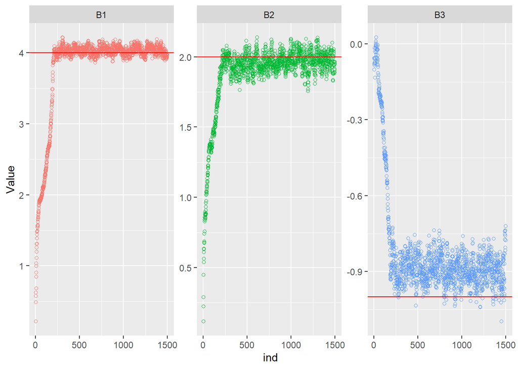

```r
Beta.Track %>%
  t() %>%
  data.frame() %>%
  set_names(c("B1", "B2", "B3")) %>%
  mutate(ind = 1:nrow(.)) %>%
  gather("Beta", "Value", B1, B2, B3) %>%
  mutate(Z = case_when(
    Beta == "B1" ~ 4,
    Beta == "B2" ~ 2,
    Beta == "B3" ~ -1
  )) %>%
  ggplot(aes(x = ind, y = Value, color = Beta)) +
  geom_point(shape = 21) +
  facet_wrap(. ~ Beta, scales = "free_y") +
  geom_hline(aes(yintercept = Z), col = "red") +
  theme(legend.position = "none")
```

```r
cbind(
  Beta.True = c(4, 2, -1),
  Estimate = rowMeans(Beta.Track[,Burn:Its]),
  apply(Beta.Track[,Burn:Its], 1, quantile, c(.025, 0.975)) %>%
  t()
) %>%
  kable(booktabs = TRUE)
```

| Beta.True | Estimate | 2.5% | 97.5% |
| --- | --- | --- | --- |
| 4 | 4.0321287 | 3.9179995 | 4.1481470 |
| 2 | 1.9667796 | 1.8495525 | 2.0894011 |
| -1 | -0.8949208 | -0.9995372 | -0.7831226 |

The $\beta$ estimates seem to do a good job of finding the right parameters.

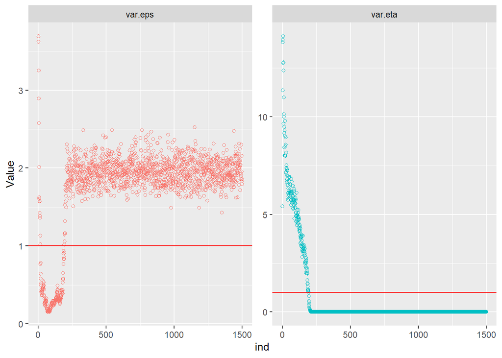

```r
data.frame(sigma2.eps.Track, sigma2.eta.Track) %>%
  set_names(c("var.eps", "var.eta")) %>%
  mutate(ind = 1:nrow(.)) %>%
  gather("Variance", "Value", var.eps, var.eta) %>%
  mutate(Z = case_when(
    Variance == "var.eps" ~ 1,
    Variance == "var.eta" ~ 1
  )) %>%
  ggplot(aes(x = ind, y = Value, color = Variance)) +
  geom_point(shape = 21) +
  facet_wrap(. ~ Variance, scales = "free_y") +
  geom_hline(aes(yintercept = Z), col = "red") +
  theme(legend.position = "none")
```

The posteriors for $\sigma^2_\varepsilon$ and $\sigma^2_\eta$ converge to the incorrect values which may increase variability of $\beta$.

## Fixed Variance

I repeated the process except fixing the variances to be their true values for each iteration rather than calculating their posteriors.

```r
#"prior" for \mu
P0 <- 10
u0 <- 0
#\beta priors
Beta.Intial <- 0
sigma2.beta <- 10

Burn <- 500
Its <- 1500

p <- ncol(X)
T <- ncol(y)
n <- nrow(y)

# This allows the user to insert a single value for all \beta prior means
if(length(Beta.Intial)  == p) Beta.Intial <- Beta.Intial else Beta.Intial <- rep(Beta.Intial, p)
B.star <- Beta.Intial

#Fix Variances
sigma2.eta.star <- 1
sigma2.eps.star <- 1

#Empty objects to track each iteration
Beta.Track <- matrix(NA, p, Its)
mu.Track <- array(NA, dim = c(n, T, Its))

#Needed for beta posterior
XtX <- matrix(0, p, p)
for(i in 1:T){
  XtX <- XtX + crossprod(i*X)
}


for(j in 1:Its){
  ###### mu post
  ##Modify y to condition on \beta
  y.star <- matrix(NA, nrow(y), ncol(y))
  for(i in 1:T)
    y.star[,i] <- y[,i] - i * X %*% B.star
  ##Run forward filtering backward sampling
  mu.star <- ffbs(y.star, sigma2.eps.star, sigma2.eta.star, u0, P0)$x
  mu.Track[,,j] <- mu.star

  # ##### Sigma NR
  # nv <- sum((y.star - mu.star)^2)
  # sigma2.eps.star <- sigma2.eps.Track[j] <- 1/rgamma(1, (n*T/2 +c0), d0+nv/2)
  #
  # np <- sum(apply(mu.star, 1, diff)^2)
  # sigma2.eta.star <- sigma2.eta.Track[j] <- 1/rgamma(1, (n*T/ 2 + a0), (b0 + np/ 2))

  #### Beta Post
  v.star <- (y-mu.star)
  B.sum <- numeric(p)
  for(i in 1:ncol(v.star))
    B.sum <- B.sum + crossprod(v.star[,i], i * X)
  B.Big <- sigma2.beta * B.sum + sigma2.eta.star * Beta.Intial
  Sigma <- sigma2.beta * XtX + diag(sigma2.eps.star, p)
  B.star <- Beta.Track[,j] <- mvtnorm::rmvnorm(1, mean = solve(Sigma, t(B.Big)), sigma = solve(Sigma) * sigma2.eps.star * sigma2.beta)[1,]
}
```

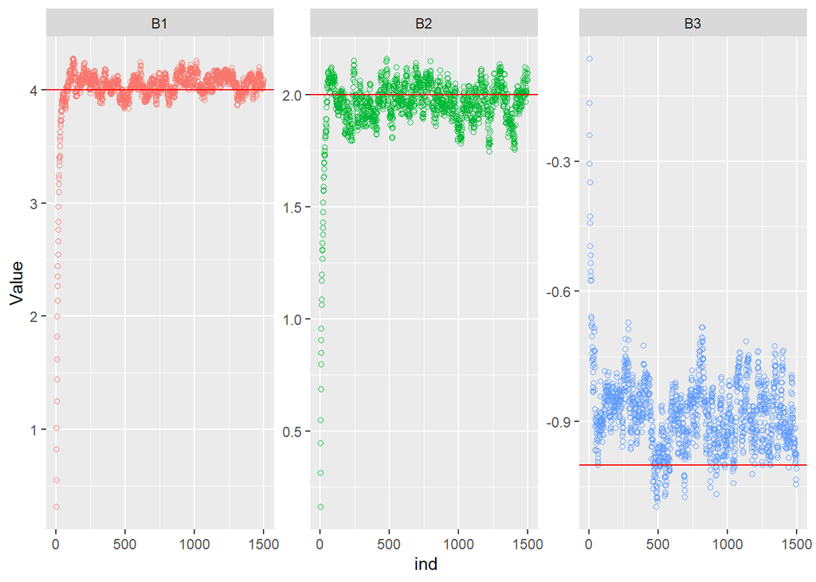

```r
Beta.Track %>%
  t() %>%
  data.frame() %>%
  set_names(c("B1", "B2", "B3")) %>%
  mutate(ind = 1:nrow(.)) %>%
  gather("Beta", "Value", B1, B2, B3) %>%
  mutate(Z = case_when(
    Beta == "B1" ~ 4,
    Beta == "B2" ~ 2,
    Beta == "B3" ~ -1
  )) %>%
  ggplot(aes(x = ind, y = Value, color = Beta)) +
  geom_point(shape = 21) +
  facet_wrap(. ~ Beta, scales = "free_y") +
  geom_hline(aes(yintercept = Z), col = "red") +
  theme(legend.position = "none")
```

```r
cbind(
  Beta.True = c(4, 2, -1),
  Estimate = rowMeans(Beta.Track[,Burn:Its]),
  apply(Beta.Track[,Burn:Its], 1, quantile, c(.025, 0.975)) %>%
  t()
) %>%
  kable(booktabs = TRUE)
```

| Beta.True | Estimate | 2.5% | 97.5% |
| --- | --- | --- | --- |
| 4 | 4.0515569 | 3.902652 | 4.1887027 |
| 2 | 1.9717914 | 1.803375 | 2.1034559 |
| -1 | -0.8969277 | -1.020938 | -0.7523709 |

Even though we condition on the true variances it doesn’t seem help our estimates much.

## Fixed $\beta$

I again went through the same process, but with this time fixing $\beta$

```r
set.seed(2438)

n <- 100
B <- 0
p <- length(B)
X <- matrix(0, n, p)

### Simulates the data
y <- ss.simp.sim(X, B, 4, P0 = 1, u0 = 0)

#"prior" for \mu
P0 <- 10
u0 <- 0
#\sigma^2_\eta priors
a0 <- .01
b0 <- .01
#\sigma^2_\varepsilon priors
c0 <- .01
d0 <- .01

Burn <- 500
Its <- 1500

p <- ncol(X)
T <- ncol(y)
n <- nrow(y)

B.star <- 0

#Mean of variances priors
sigma2.eta.star <- (d0/2)/(c0/2 + 1)
sigma2.eps.star <- (b0/2)/(a0/2 + 1)

#Empty objects to track each iteration
sigma2.eps.Track <- numeric(Its)
sigma2.eta.Track <- numeric(Its)
mu.Track <- array(NA, dim = c(n, T, Its))


for(j in 1:Its){
  ###### mu post
  ##Modify y to condition on \beta
  y.star <- y
  ##Run forward filtering backward sampling
  mu.star <- ffbs(y.star, sigma2.eps.star, sigma2.eta.star, u0, P0)$x
  mu.Track[,,j] <- mu.star

  ##### Sigma NR
  nv <- sum((y.star - mu.star)^2)
  sigma2.eps.star <- sigma2.eps.Track[j] <- 1/rgamma(1, (n*T/2 +c0), d0+nv/2)

  np <- sum(apply(mu.star, 1, diff)^2)
  sigma2.eta.star <- sigma2.eta.Track[j] <- 1/rgamma(1, (n*T/ 2 + a0), (b0 + np/ 2))

  #### Beta Post
  # v.star <- (y-mu.star)
  # B.sum <- numeric(p)
  # for(i in 1:ncol(v.star))
  #   B.sum <- B.sum + crossprod(v.star[,i], i * X)
  # B.Big <- sigma2.beta * B.sum + sigma2.eta.star * Beta.Intial
  # Sigma <- sigma2.beta * XtX + diag(sigma2.eps.star, p)
  # B.star <- Beta.Track[,j] <- mvtnorm::rmvnorm(1, mean = solve(Sigma, t(B.Big)), sigma = solve(Sigma) * sigma2.eps.star * sigma2.beta)[1,]
}
```

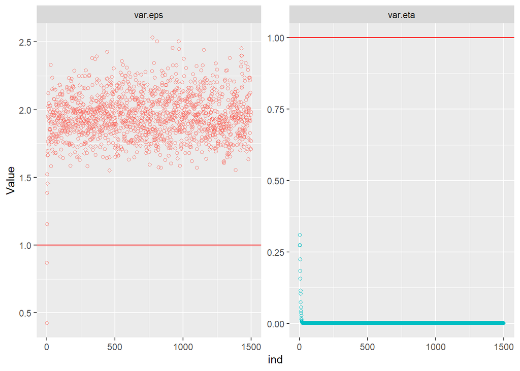

```r
data.frame(sigma2.eps.Track, sigma2.eta.Track) %>%
  set_names(c("var.eps", "var.eta")) %>%
  mutate(ind = 1:nrow(.)) %>%
  gather("Variance", "Value", var.eps, var.eta) %>%
  mutate(Z = case_when(
    Variance == "var.eps" ~ 1,
    Variance == "var.eta" ~ 1
  )) %>%
  ggplot(aes(x = ind, y = Value, color = Variance)) +
  geom_point(shape = 21) +
  facet_wrap(. ~ Variance, scales = "free_y") +
  geom_hline(aes(yintercept = Z), col = "red") +
  theme(legend.position = "none")
```

## Fixing $\beta$ and increase $T = 100$

```r
set.seed(2438)

n <- 100
B <- 0
p <- length(B)
X <- matrix(0, n, p)

### Simulates the data
y <- ss.simp.sim(X, B, 100, P0 = 1, u0 = 0)

#"prior" for \mu
P0 <- 10
u0 <- 0
#\sigma^2_\eta priors
a0 <- .01
b0 <- .01
#\sigma^2_\varepsilon priors
c0 <- .01
d0 <- .01

Burn <- 500
Its <- 1500

p <- ncol(X)
T <- ncol(y)
n <- nrow(y)

B.star <- 0

#Mean of variances priors
sigma2.eta.star <- (d0/2)/(c0/2 + 1)
sigma2.eps.star <- (b0/2)/(a0/2 + 1)

#Empty objects to track each iteration
sigma2.eps.Track <- numeric(Its)
sigma2.eta.Track <- numeric(Its)
mu.Track <- array(NA, dim = c(n, T, Its))


for(j in 1:Its){
  ###### mu post
  ##Modify y to condition on \beta
  y.star <- y
  ##Run forward filtering backward sampling
  mu.star <- ffbs(y.star, sigma2.eps.star, sigma2.eta.star, u0, P0)$x
  mu.Track[,,j] <- mu.star

  ##### Sigma NR
  nv <- sum((y.star - mu.star)^2)
  sigma2.eps.star <- sigma2.eps.Track[j] <- 1/rgamma(1, (n*T/2 +c0), d0+nv/2)

  np <- sum(apply(mu.star, 1, diff)^2)
  sigma2.eta.star <- sigma2.eta.Track[j] <- 1/rgamma(1, (n*T/ 2 + a0), (b0 + np/ 2))

  #### Beta Post
  # v.star <- (y-mu.star)
  # B.sum <- numeric(p)
  # for(i in 1:ncol(v.star))
  #   B.sum <- B.sum + crossprod(v.star[,i], i * X)
  # B.Big <- sigma2.beta * B.sum + sigma2.eta.star * Beta.Intial
  # Sigma <- sigma2.beta * XtX + diag(sigma2.eps.star, p)
  # B.star <- Beta.Track[,j] <- mvtnorm::rmvnorm(1, mean = solve(Sigma, t(B.Big)), sigma = solve(Sigma) * sigma2.eps.star * sigma2.beta)[1,]
}
```

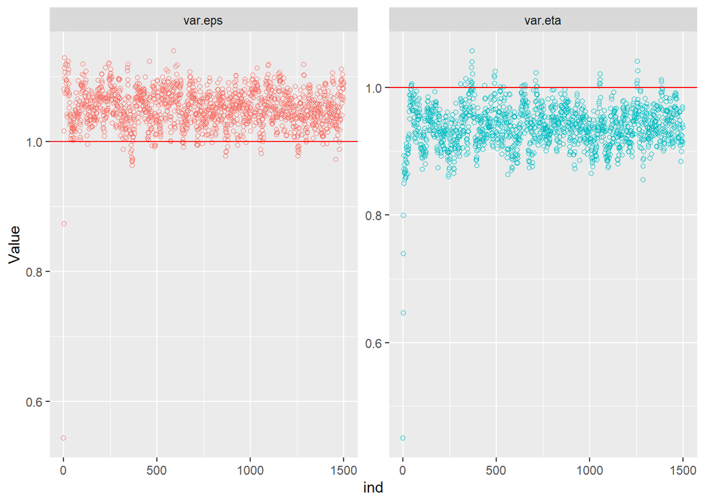

```r
data.frame(sigma2.eps.Track, sigma2.eta.Track) %>%
  set_names(c("var.eps", "var.eta")) %>%
  mutate(ind = 1:nrow(.)) %>%
  gather("Variance", "Value", var.eps, var.eta) %>%
  mutate(Z = case_when(
    Variance == "var.eps" ~ 1,
    Variance == "var.eta" ~ 1
  )) %>%
  ggplot(aes(x = ind, y = Value, color = Variance)) +
  geom_point(shape = 21) +
  facet_wrap(. ~ Variance, scales = "free_y") +
  geom_hline(aes(yintercept = Z), col = "red") +
  theme(legend.position = "none")
```

The variances get much closer to their true value.

## Estimating Both Parameters with $T = 100$

```r
n <- 100
B <- c(4, 2, -1)
# B <- 0
p <- length(B)
X <- matrix(rnorm(n*p), n, p)

### Simulates the data
set.seed(2438)
y <- ss.simp.sim(X, B, 100, P0 = 1, u0 = 0)

#"prior" for \mu
P0 <- 10
u0 <- 0
#\beta priors
Beta.Intial <- 0
sigma2.beta <- 10
#\sigma^2_\eta priors
a0 <- .01
b0 <- .01
#\sigma^2_\varepsilon priors
c0 <- .01
d0 <- .01

Burn <- 500
Its <- 1500

p <- ncol(X)
T <- ncol(y)
n <- nrow(y)

# This allows the user to insert a single value for all \beta prior means
if(length(Beta.Intial)  == p) Beta.Intial <- Beta.Intial else Beta.Intial <- rep(Beta.Intial, p)
B.star <- Beta.Intial

#Mean of variances priors
sigma2.eta.star <- (d0/2)/(c0/2 + 1)
sigma2.eps.star <- (b0/2)/(a0/2 + 1)

#Empty objects to track each iteration
Beta.Track <- matrix(NA, p, Its)
sigma2.eps.Track <- numeric(Its)
sigma2.eta.Track <- numeric(Its)
mu.Track <- array(NA, dim = c(n, T, Its))


#Needed for beta posterior
XtX <- matrix(0, p, p)
for(i in 1:T){
  XtX <- XtX + crossprod(i*X)
}


for(j in 1:Its){
  ###### mu post
  ##Modify y to condition on \beta
  y.star <- matrix(NA, nrow(y), ncol(y))
  for(i in 1:T)
    y.star[,i] <- y[,i] - i * X %*% B.star
  ##Run forward filtering backward sampling
  mu.star <- ffbs(y.star, sigma2.eps.star, sigma2.eta.star, u0, P0)$x
  mu.Track[,,j] <- mu.star

  ##### Sigma NR
  nv <- sum((y.star - mu.star)^2)
  sigma2.eps.star <- sigma2.eps.Track[j] <- 1/rgamma(1, (n*T/2 +c0), d0+nv/2)

  np <- sum(apply(mu.star, 1, diff)^2)
  sigma2.eta.star <- sigma2.eta.Track[j] <- 1/rgamma(1, (n*T/ 2 + a0), (b0 + np/ 2))

  #### Beta Post
  v.star <- (y-mu.star)
  B.sum <- numeric(p)
  for(i in 1:ncol(v.star))
    B.sum <- B.sum + crossprod(v.star[,i], i * X)
  B.Big <- sigma2.beta * B.sum + sigma2.eta.star * Beta.Intial
  Sigma <- sigma2.beta * XtX + diag(sigma2.eps.star, p)
  B.star <- Beta.Track[,j] <- mvtnorm::rmvnorm(1, mean = solve(Sigma, t(B.Big)), sigma = solve(Sigma) * sigma2.eps.star * sigma2.beta)[1,]
}
```

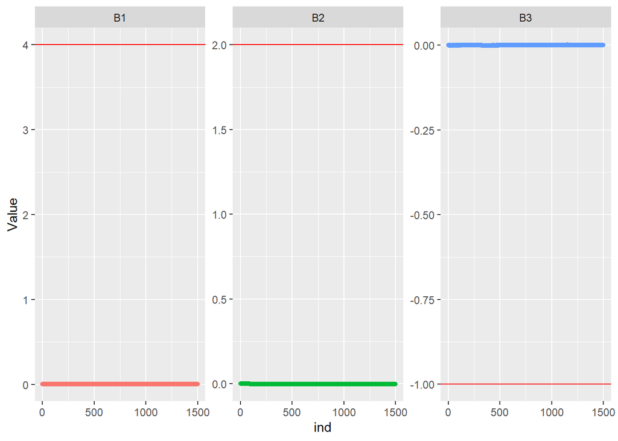

```r
Beta.Track %>%
  t() %>%
  data.frame() %>%
  set_names(c("B1", "B2", "B3")) %>%
  mutate(ind = 1:nrow(.)) %>%
  gather("Beta", "Value", B1, B2, B3) %>%
  mutate(Z = case_when(
    Beta == "B1" ~ 4,
    Beta == "B2" ~ 2,
    Beta == "B3" ~ -1
  )) %>%
  ggplot(aes(x = ind, y = Value, color = Beta)) +
  geom_point(shape = 21) +
  facet_wrap(. ~ Beta, scales = "free_y") +
  geom_hline(aes(yintercept = Z), col = "red") +
  theme(legend.position = "none")
```

Not even close… I’m guessing the issues here is another numerical accuracy inversion issue as $\sum_{t=1}^T X_t'X_t$ portion of $\Sigma$ will get very large as $T$ increases.

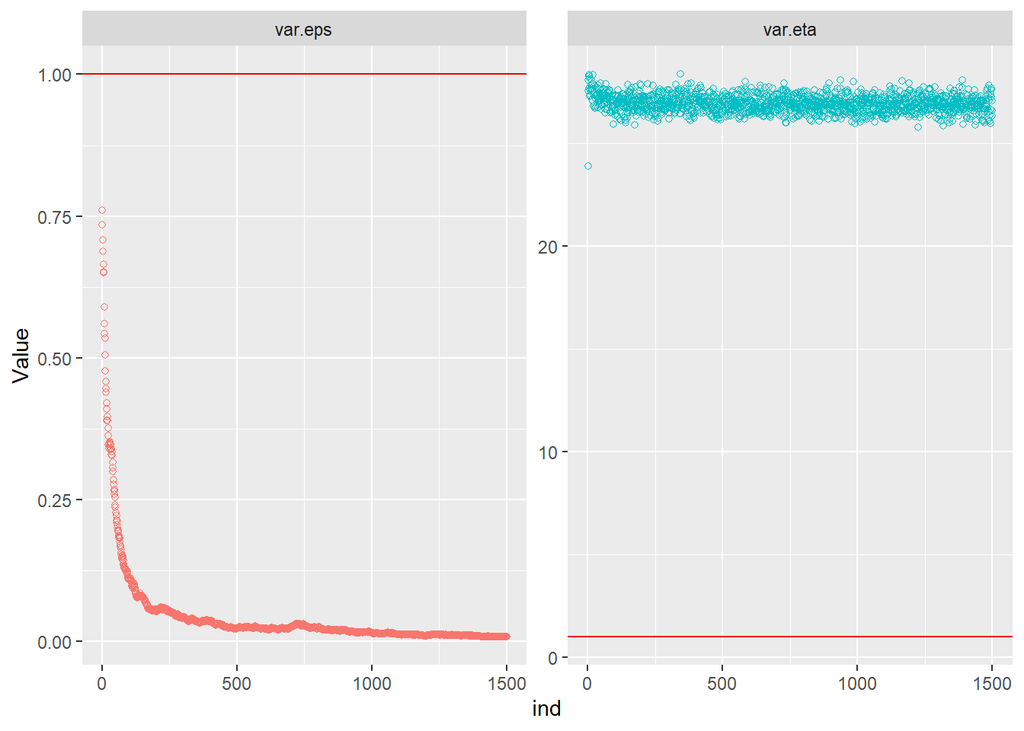

```r
data.frame(sigma2.eps.Track, sigma2.eta.Track) %>%
  set_names(c("var.eps", "var.eta")) %>%
  mutate(ind = 1:nrow(.)) %>%
  gather("Variance", "Value", var.eps, var.eta) %>%
  mutate(Z = case_when(
    Variance == "var.eps" ~ 1,
    Variance == "var.eta" ~ 1
  )) %>%
  ggplot(aes(x = ind, y = Value, color = Variance)) +
  geom_point(shape = 21) +
  facet_wrap(. ~ Variance, scales = "free_y") +
  geom_hline(aes(yintercept = Z), col = "red") +
  theme(legend.position = "none")
```